# Data manipulations

Julia van Hees

April 5th, 2020

**Included in this file:**

- Load part 1 (derivation cohort) data into R and check data quality
- Load part 2 (validation cohort) data into R and check data quality
- Clinical variable distributions
- Treatment variable distributions
- Imaging variable distributions
- Vascular Anatomical variable distributions

## Load part 1 (derivation cohort) data into R and check data quality

```r
library(foreign, quietly = TRUE)
library(Hmisc, quietly = TRUE)
part1 <- read.spss("Part1.sav", to.data.frame = TRUE, use.value.labels = TRUE)
```

See the first row of part1 and see what variables are included

```r
part1[1,]
```

```
##   Mc_FailedFemoralApproach M_posttici_c M_durproc M_mrs_rev       M_collaterals
## 1                        0            0       110         0 >50% but less <100%
##   Mc_pretici_short M_premrs M_ivtrom M_prev_str M_prev_dm M_prev_af M_rr_syst
## 1                0        1        1        Yes       Yes       Yes       146
##   M_NIHSS_FU M_age M_prev_ht M_sex M_NIHSS_BL M_togroin M_ASPECTS_BL M_CBS_BL
## 1         NA    80        No  Male         22       130            6        6
##   M_occlsegment_c_short AorticVariant ArchElongation AngleFollowingBifurcation
## 1                    M1        Type C             II    No angle >= 90 degrees
##   AngleAaInn_OR_AaCca AngleCcaIca InnCca_nr_90orLarger ICA_nr_90orLarger
## 1                 138          44                    0                 3
##   InnAtherosclerosis InnOrigin  CcaAherosclerosis CCAOrigin ICAEAtherosclerosis
## 1      Yes, stenosis       Yes Yes, <50% stenosis      Both       Yes, stenosis
##   ICAE_NASCET_Degree ICAIAtherosclerosis      sidescored AorticVariant_dichC
## 1               62.8 Yes, >=50% stenosis Left hemisphere              Type C
##   AorticVariant_dichB ArchElongation_dichIII InnCca_90orLarger ICA_90orLarger
## 1 Type A, C, D, other           Type I or II                 1              1
##   AngleAaInn_OR_AaCca_dich45          OrigoStenosis50percent ICAE_NASCET_70
## 1               > 45 degrees stenosis < 50% or not at origin              1
##   ICAI_stenosis50
## 1   Stenose >=50%
```

Retrieve the dimensions of part1 (how many variables, rows and columns)

```r
dim(part1)
```

```
## [1] 887  45
```

Get some information on each variable, such as mean, highest value or missings etc

```r
describe(part1)
```

```
## part1
##
##  45  Variables      887  Observations
## --------------------------------------------------------------------------------
## Mc_FailedFemoralApproach
##        n  missing distinct     Info      Sum     Mean      Gmd
##      887        0        2    0.186       59  0.06652   0.1243
##
## --------------------------------------------------------------------------------
## M_posttici_c
##        n  missing distinct
##      877       10        6
##
## lowest : 0  1  2A 2B 2C, highest: 1  2A 2B 2C 3
##
## Value          0     1    2A    2B    2C     3
## Frequency    171    32   192   162    85   235
## Proportion 0.195 0.036 0.219 0.185 0.097 0.268
## --------------------------------------------------------------------------------
## M_durproc
##        n  missing distinct     Info     Mean      Gmd      .05      .10
##      798       89      137    0.999     70.1    37.44     25.0     30.0
##      .25      .50      .75      .90      .95
##     45.0     65.0     90.0    118.3    132.3
##
## lowest :  10  13  16  17  18, highest: 171 175 180 188 221
## --------------------------------------------------------------------------------
## M_mrs_rev
##        n  missing distinct     Info     Mean      Gmd
##      814       73        7    0.959    2.489    2.272
##
## lowest : 0 1 2 3 4, highest: 2 3 4 5 6
##
## Value          0     1     2     3     4     5     6
## Frequency    244    47   103   110   155   107    48
## Proportion 0.300 0.058 0.127 0.135 0.190 0.131 0.059
## --------------------------------------------------------------------------------
## M_collaterals
##        n  missing distinct
##      853       34        4
```

[output cut: 342 more lines]

```
##        n  missing distinct
##      770      117        2
##
## Value          1     2
## Frequency    676    94
## Proportion 0.878 0.122
## --------------------------------------------------------------------------------
## ICAI_stenosis50
##        n  missing distinct
##      665      222        2
##
## Value      Stenosis < 50%  Stenose >=50%
## Frequency             554            111
## Proportion          0.833          0.167
## --------------------------------------------------------------------------------
```

## Load part 2 (validation cohort) data into R and check data quality

```r
part2 <- read.spss("Part2.sav", to.data.frame = TRUE, use.value.labels = TRUE)
```

See the first row of part1 and see what variables are included

```r
part2[1,]
```

```
##   Mc_FailedFemoralApproach    M_age M_prev_ht AorticVariant ArchElongation
## 1                        1 31.46886        No          <NA>           <NA>
##   AngleFollowingBifurcation InnCca_nr_90orLarger AorticVariant_dichC
## 1                        no                 <NA>                <NA>
##   ArchElongation_dichIII InnCca_90orLarger ICAE_NASCET_Degree ICAE_NASCET_70
## 1                   <NA>              <NA>                  0            <70
##   M_posttici_c M_durproc M_mrs_rev         M_collaterals M_pretici_c M_premrs
## 1            0        40         5 100% of occluded area           0        1
##   M_ivtrom M_prev_str M_prev_dm M_prev_af M_rr_syst M_NIHSS_FU  M_sex
## 1        2         No        No        No       123          0 Female
##   M_NIHSS_BL M_togroin M_ASPECTS_BL M_CBS_BL M_occlsegment_c_short
## 1          5       155            9        6                    M1
##         occlside_c
## 1 Right hemisphere
```

Retrieve the dimensions of part1 (how many variables, rows and columns)

```r
dim(part2)
```

```
## [1] 1120   31
```

Get some information on each variable, such as mean, highest value or missings etc.

```r
describe(part2)
```

```
## part2
##
##  31  Variables      1120  Observations
## --------------------------------------------------------------------------------
## Mc_FailedFemoralApproach
##        n  missing distinct     Info      Sum     Mean      Gmd
##     1120        0        2    0.199       80  0.07143   0.1328
##
## --------------------------------------------------------------------------------
## M_age
##        n  missing distinct     Info     Mean      Gmd      .05      .10
##     1120        0     1064        1    70.59    15.68    44.32    51.26
##      .25      .50      .75      .90      .95
##    62.31    72.89    80.92    86.79    88.81
##
## lowest :  18.23682  19.39220  25.48392  25.92745  27.33196
## highest:  97.59343  97.85352  98.40931  99.88775 102.70773
## --------------------------------------------------------------------------------
## M_prev_ht
##        n  missing distinct
##     1112        8        2
##
## Value         No   Yes
## Frequency    493   619
## Proportion 0.443 0.557
## --------------------------------------------------------------------------------
## AorticVariant
##        n  missing distinct
##     1099       21        3
##
## Value          A     B     C
## Frequency    746   162   191
## Proportion 0.679 0.147 0.174
## --------------------------------------------------------------------------------
## ArchElongation
##        n  missing distinct
##     1112        8        3
##
## Value          I    II   III
## Frequency    191   705   216
```

[output cut: 221 more lines]

```
## Frequency                    52                  230                  637
## Proportion                0.048                0.212                0.586
##
## Value      other:M3/anterior_M2
## Frequency                   168
## Proportion                0.155
## --------------------------------------------------------------------------------
## occlside_c
##        n  missing distinct
##     1120        0        2
##
## Value       Left hemisphere Right hemisphere
## Frequency               608              512
## Proportion            0.543            0.457
## --------------------------------------------------------------------------------
```

## Clinical variable distributions

The distribution of numeric (continuous) variables was determined first. Start with M_age. Check if normally distributed. If the Shapiro-Wilk test p>0.05, then normality can be assumed.

```r
shapiro.test(part1$M_age) # w=0.96, p=1.1e-14
```

```
##
##  Shapiro-Wilk normality test
##
## data:  part1$M_age
## W = 0.96079, p-value = 1.118e-14
```

Also check with a histogram:

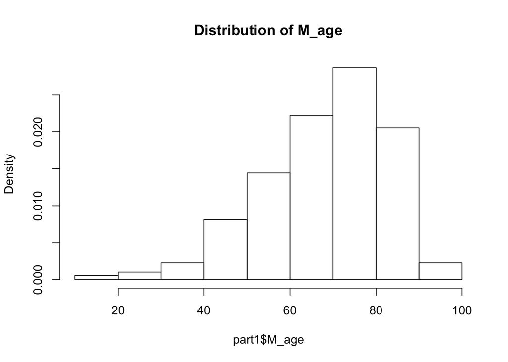

```r
par(mfrow=c(1,1))
hist(part1$M_age,probability = T, main = "Distribution of M_age" )
```

And a QQplot:

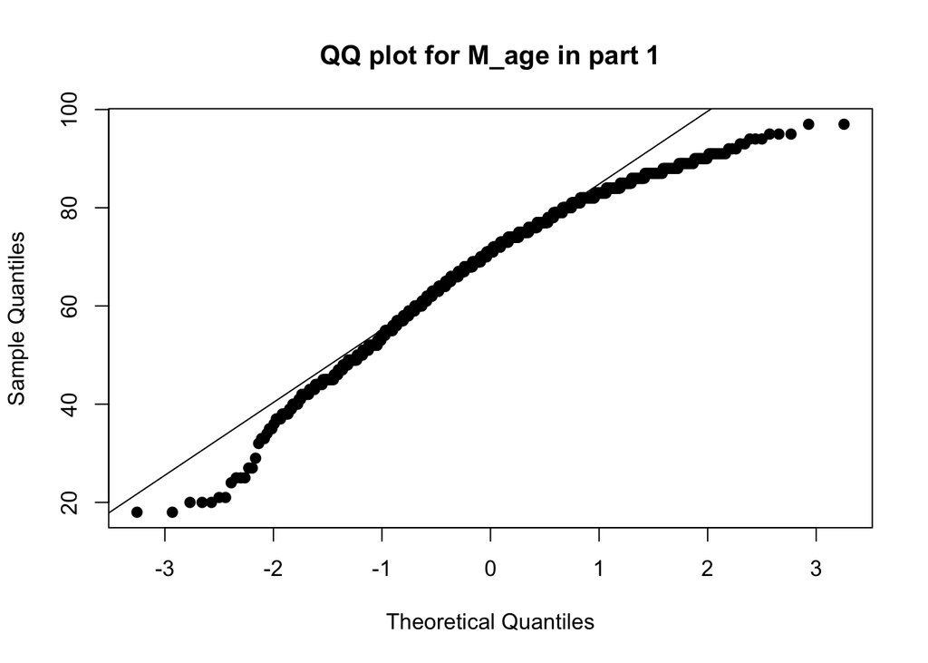

```r
qqnorm(part1$M_age, main = "QQ plot for M_age in part 1", pch=19)
qqline(part1$M_age)
```

```r
library(plyr)
median <- median(part1$M_age, na.rm = TRUE)
iqr <- IQR(part1$M_age, na.rm = TRUE)
iqr_low <- quantile(part1$M_age, na.rm = TRUE)[2]
iqr_high <- quantile(part1$M_age, na.rm = TRUE)[4]
print(median)
```

```
## [1] 71
```

```r
print(iqr_low)
```

```
## 25%
##  60
```